# Comparison of suicide/homicide rates between races

2020-09-07

It is unknown how much the difference in excess deaths due to homicide among black men and suicide among white men vary by US state.

To compare the rates of firearm and non-firearm homicide and suicide in black and white non-Hispanic men by US state and examine their associations with state prevalence of gun ownership.

# The relationship between the annual rates of firearm homicide and suicide among white men

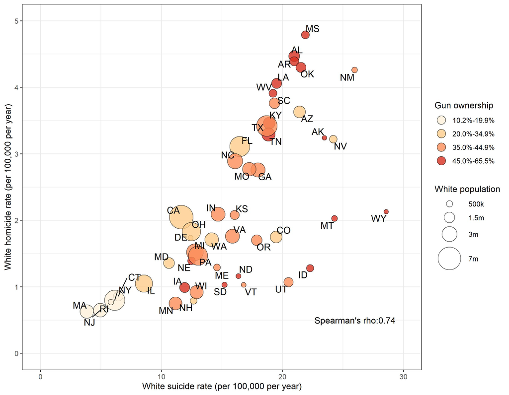

[figure not shown]

```r
# Discover the relationship between tha annual rates of firearm homicide and suicide among white men

library(dplyr)
library(ggplot2)
library(ggrepel)

white_firearm <- vroom::vroom(here::here("data","CDC_Males.csv")) %>%
  filter(type == 'Firearm' & !(ST %in% c("US", "DC", "HI")))


white_firearm_plot <- ggplot(data = white_firearm, aes(x = adjusted.suicide.White, y = adjusted.homicide.White))+
  geom_point(aes(fill = gun.house.prev.category, size = average.pop.white), col = "black", pch = 21, alpha = 0.8)+
  scale_fill_manual(values = c("#fef0d9", "#fdcc8a", "#fc8d59", "#d7301f"))+
  scale_size_area(breaks = c(500000, 1500000, 3000000, 7000000), max_size = 14, labels = c('500k', '1.5m', '3m', '7m'))+
  scale_x_continuous(limits = c(0,30))+
  scale_y_continuous(limits = c(0,5))+
  labs(x = 'White suicide rate (per 100,000 per year)', y = 'White homicide rate (per 100,000 per year)')+
  guides(fill = guide_legend(title = 'Gun ownership',override.aes = list(size = 5), order = 1),
         size = guide_legend(title = 'White population', order = 0))+
  geom_text_repel(aes(label = ST), size = 4.2)+
  geom_text(aes(x = 26, y = 0.5, label = paste0("Spearman's rho:0.74")),check_overlap = TRUE)+
  theme_bw()+
  NULL

ggsave("white_firearm_plot.jpg",plot = white_firearm_plot, width = 9, height = 7, path = here::here("static/img"))
knitr::include_graphics(here::here("static/img", "white_firearm_plot.jpg"))
```

From the plot, we can see that firearm homicide and suicide were strongly associated for white men. In terms of the relationship among firearm homicide, suicide, and state gun prevalence, the 5 states with lower rates of both firearm homicide and suicide in white men(Massachusetts, New Jersey, Rhode Island, New York, Connecticut)also were in the lowest category of reported state gun prevalence.

# The relationship between the annual rates of firearm homicide and suicide among black men

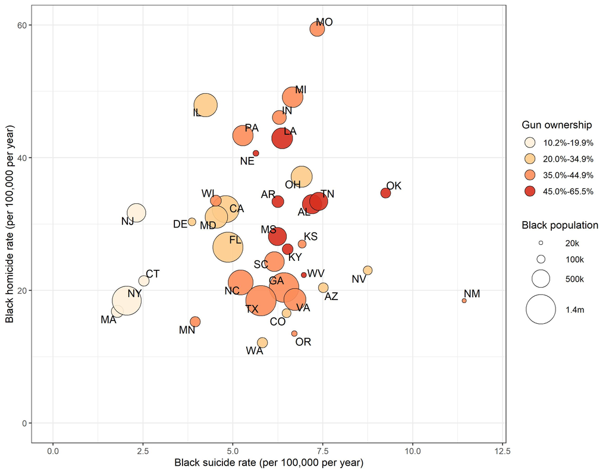

```r
# Discover the relationship between tha annual rates of firearm homicide and suicide among black men

black_firearm_plot <- ggplot(subset(white_firearm, type == "Firearm" & !(ST %in% c("US", "DC"))), aes(x = adjusted.suicide.Black, y = adjusted.homicide.Black)) +
  geom_point(aes(fill = gun.house.prev.category, size = average.pop.black), col = "black", pch = 21, alpha = 0.9) +
  geom_text_repel(aes(label = ST), size = 4, check_overlap = T) +
  scale_fill_manual(values = c("#fef0d9", "#fdcc8a", "#fc8d59", "#d7301f")) +
  labs(x = 'Black suicide rate (per 100,000 per year)', y = 'Black homicide rate (per 100,000 per year)')+
  scale_y_continuous(limits = c(0, 60)) +
  scale_x_continuous(limits = c(0, 12)) +
  theme_bw() +
  scale_size_area(breaks = c(20000, 100000, 500000, 1400000),
                  labels = c("20k", "100k", "500k", "1.4m"),
                  max_size = 15) +
  guides(fill = guide_legend(title = "Gun ownership",
                             override.aes = list(size = 5), order = 1),
         size = guide_legend(title = "Black population"), order = 2) +
         geom_text(aes(x = 26, y = 0.5, label = paste0("Spearman's rho:0.34")), check_overlap = TRUE)+
  theme_bw()+
  NULL


ggsave("black_firearm_plot.jpg",plot = black_firearm_plot, width = 9, height = 7, path = here::here("static/img"))
knitr::include_graphics(here::here("static/img", "black_firearm_plot.jpg"))
```

Among black men, firearm homicide and suicide were modestly associated. States with the lowest reported prevalence of guns had the lowest rates of firearm suicide and below-average rates of firearm homicide. Missouri and several rust belt states reported the most firearm homicides among black men but medium levels of gun ownership.

# Results further explanation